# Harry Potter SAOM

Franziska Köstler, Cindy Ekaterina Batchy-Tom

2023-12-21

# **Blood status in Harry Potter**

The different wizards at Hogwarts are not all the same. Although they are able to use their wizarding powers and are therefore eligible to attend the school, their ancestry and wizarding blood type can vary. Some have at least one wizarding parent (pure-blood, half-blood) and others have parents without any magical powers (muggle-born). A core part of deatheater ideology is the discrimination against muggles and muggle-born wizards and pure-blood wizard supremacy as evidence by the eventual exclusion of all muggle-born students from Hogwarts after the deatheater takeover in book 7. As they plan and successfully orchestrate their master Lord Voldemort’s comeback over the books 2 to 4, does this coincide with a resurgence of their discriminatory ideology? Do these monadic determinants of blood status lead to differential treatment of pupils in the peer support networks at Hogwarts?

### **Hypotheses:**

The following hypotheses have been formulated:

H1: Students are more likely to form support ties with peers of the same blood status.

H2: Pureblood students are more likely to receive support ties from other students.

### **Data sample and visualization:**

The aim of this blog post is to analyse blood status heterogeneity and the evolution of peer support network formation in the three books (2-4), using the Harry Potter data set from [Bossaert and Meidert (2013)](https://www.scirp.org/pdf/OJAppS_2013062013240776.pdf). The additional attribute of blood status was coded as 1: muggle born, 2: unclear but not muggle-born, 3: halfblood, 4: pureblood.

[figure not shown]

*Harry Potter and the Chamber of Secrets*

[figure not shown]

*Harry Potter and the Prisoner of Azkabahn*

[figure not shown]

*Harry Potter and the Goblet of Fire*

### **Model specification:**

Following the [RSiena manual](https://www.stats.ox.ac.uk/~snijders/siena/RSiena_Manual.pdf) and [Wimmer and Lewis 2010](http://www.kailchan.ca/wp-content/uploads/2013/07/WimmerLewis-AJS-2010_Beyond-and-below-racial-homophily.pdf) recommendations on default structural effects, the following ones were included in the model: outdegree (density), reciprocity, transitive triplets, 3-cycles, GEWSP, indegree popularity, outdegree activity and indegree activity.

The covariate effects were chosen based on the hypotheses: Following H1 blood similarity was included. In a later specification of the model this was altered to homophily (egoXaltX). H2 lead to the inclusion of alter related blood status to account for popularity. In addition, ego related blood status was included to check if sociability also played a role. The model also controls for same house, gender and schoolyear. Time heterogeneity was also taken into account with the result of replacing the time heterogeneous covariate effects of house and schoolyear with new time-varying variables.

### **Results:**

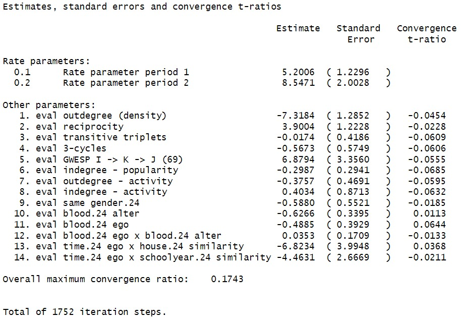

### **Goodness of fit:**

The Goodness of fit function compares the simulated network models with the actual networks of books 2 to 4, with a p value > 0.05 suggesting a reasonable fit. This is the case for the model.

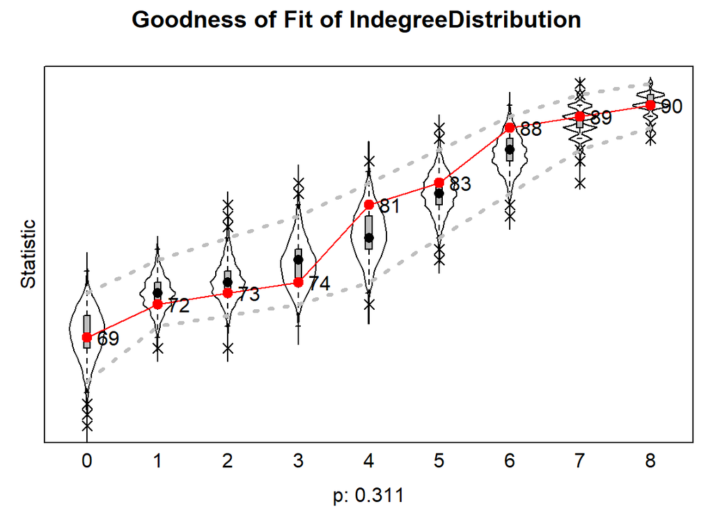

*Indegree Goodness of Fit*

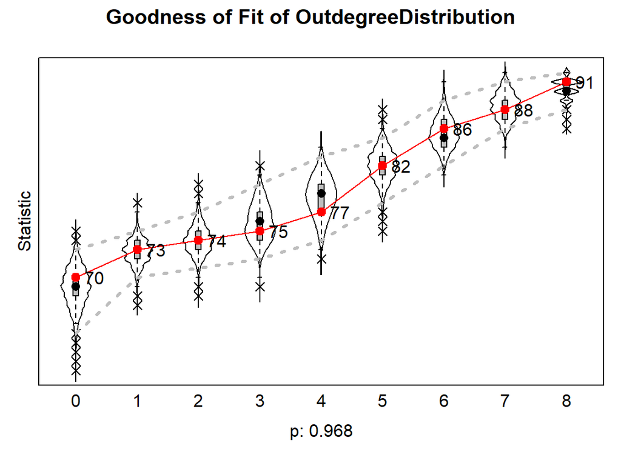

*Outdegree Goodness of Fit*

### **Discussion and limitations**:

In interpreting the results it should be noted that the sample is biased towards Harry Potter and his close friends, including the big and pureblood Weasley family. Furthermore, the specifications of the model to consider time heterogeneity worsened the overall convergence of the model, even if the threshold remained acceptable. Future analyses could consider these factors and explore not only subsequent books, but also whether the multiple indirect pathways through which racial homogeneity can manifest are better applicable to blood status in Harry Potter, as conceptualised in [Wimmer and Lewis 2010](http://www.kailchan.ca/wp-content/uploads/2013/07/WimmerLewis-AJS-2010_Beyond-and-below-racial-homophily.pdf).